# Multiple regression

## Multiple regression

$$\LARGE{\text{outcome} = \text{model} + \text{error}}$$

In statistics, linear regression is a linear approach for modeling the relationship between a scalar dependent variable y and one or more explanatory variables denoted X.

$$\LARGE{Y_i = \beta_0 + \beta_1 X_{1i} + \beta_2 X_{2i} + \dotso + \beta_n X_{ni} + \epsilon_i}$$

In linear regression, the relationships are modeled using linear predictor functions whose unknown model parameters $\beta$’s are estimated from the data.

Source: [wikipedia](https://en.wikipedia.org/wiki/Linear_regression)

## Outcome vs Model

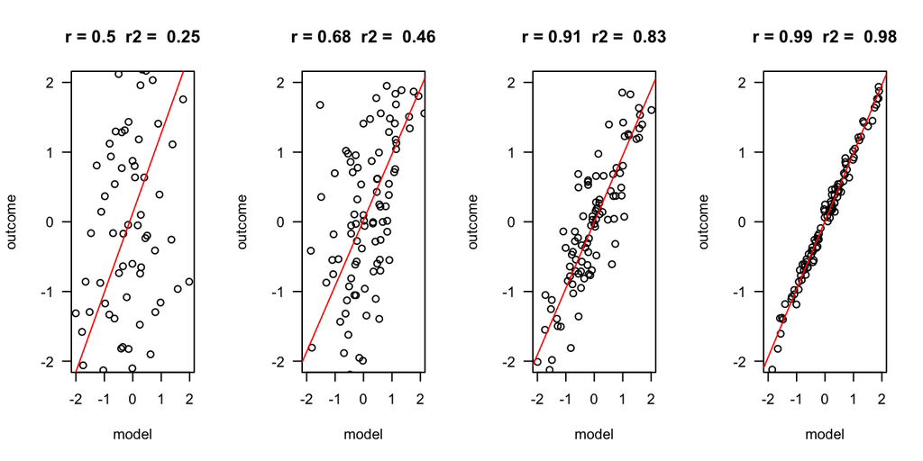

```r
error = c(2, 1, .5, .1)
n = 100

layout(matrix(1:4,1,4))
for(e in error) {

  x = rnorm(n)
  y = x + rnorm(n, 0 , e)

  r   = round(cor(x,y), 2)
  r.2 = round(r^2, 2)

  plot(x,y, las = 1, ylab = "outcome", xlab = "model", main = paste("r =", r," r2 = ", r.2), ylim=c(-2,2), xlim=c(-2,2))
  fit <- lm(y ~ x)
  abline(fit, col = "red")

}
```

## Assumptions

A selection from Field (8.3.2.1. Assumptions of the linear model):

- Sensitivity
- Homoscedasticity
- Multicollinearity
- Linearity

## Multicollinearity

[figure not shown]

To adhere to the multicollinearity assumptien, there must not be a too high linear relation between the predictor variables.

This can be assessed through:

- Correlations
- Matrix scatterplot
- VIF: max < 10, mean < 1
- Tolerance > 0.2

## Read data

```r
data <- read.csv('IQ.csv', header=T)

head(data)
```

```
##   Studieprestatie Motivatie       IQ
## 1        2.710330  3.276778 129.9922
## 2        2.922617  2.598901 128.4936
## 3        1.997056  3.207279 130.2709
## 4        2.322539  2.104968 125.7457
## 5        2.162133  3.264948 128.6770
## 6        2.278899  2.217771 127.5349
```

```r
IQ              = data$IQ
Studieprestatie = data$Studieprestatie
Motivatie       = data$Motivatie
```

## Regressie model in R

studie prestatie voorspellen op basis van IQ en motivatie

```r
fit <- lm(Studieprestatie ~ IQ + Motivatie)
```

## Wat is het regressie model

```r
fit$coefficients
```

```
## (Intercept)          IQ   Motivatie
## -30.2822189   0.2690984  -0.6314253
```

```r
b.0 = fit$coefficients[1] ## Intercept
b.1 = fit$coefficients[2] ## Beta coefficient voor IQ
b.2 = fit$coefficients[3] ## Beta coefficient voor Motivatie
```

De beta coëfficienten zijn:

- $b_0$ (intercept) = -30.2822189
- $b_1$ = 0.2690984
- $b_2$ = -0.6314253.

## Wat zijn de verwachte waarden op basis van dit model

$$\widehat{\text{studie prestatie}} = b_0 + b_1 \text{IQ} + b_2 \text{Motivatie}$$

```r
exp.stu.prest = b.0 + b.1 * IQ + b.2 * Motivatie

model = exp.stu.prest
```

$$\text{model} = \widehat{\text{studie prestatie}}$$

## Regressie model toepassen

$$\widehat{\text{studie prestatie}} = b_0 + b_1 \text{IQ} + b_2 \text{Motivatie}$$
$$\widehat{\text{model}} = b_0 + b_1 \text{IQ} + b_2 \text{Motivatie}$$

```r
cbind(model, b.0, b.1, IQ, b.2, Motivatie)[1:5,]
```

```
##         model       b.0       b.1       IQ        b.2 Motivatie
## [1,] 2.629425 -30.28222 0.2690984 129.9922 -0.6314253  3.276778
## [2,] 2.654199 -30.28222 0.2690984 128.4936 -0.6314253  2.598901
## [3,] 2.748322 -30.28222 0.2690984 130.2709 -0.6314253  3.207279
## [4,] 2.226617 -30.28222 0.2690984 125.7457 -0.6314253  2.104968
## [5,] 2.282976 -30.28222 0.2690984 128.6770 -0.6314253  3.264948
```

$$\widehat{\text{model}} = -30.2822189 + 0.2690984 \times \text{IQ} + -0.6314253 \times \text{Motivatie}$$

## Hoever zitten we er naast?

```r
error = Studieprestatie - model

cbind(model, Studieprestatie, error)[1:5,]
```

```
##         model Studieprestatie       error
## [1,] 2.629425        2.710330  0.08090469
## [2,] 2.654199        2.922617  0.26841727
## [3,] 2.748322        1.997056 -0.75126679
## [4,] 2.226617        2.322539  0.09592146
## [5,] 2.282976        2.162133 -0.12084299
```

## Outcome = Model + Error

Is dat zo?

```r
Studieprestatie == model + error
```

```
##  [1] TRUE TRUE TRUE TRUE TRUE TRUE TRUE TRUE TRUE TRUE TRUE TRUE TRUE TRUE
## [15] TRUE TRUE TRUE TRUE TRUE TRUE TRUE TRUE TRUE TRUE TRUE TRUE TRUE TRUE
## [29] TRUE TRUE TRUE TRUE TRUE TRUE TRUE TRUE TRUE TRUE TRUE
```

> - Ja!

## Visueel

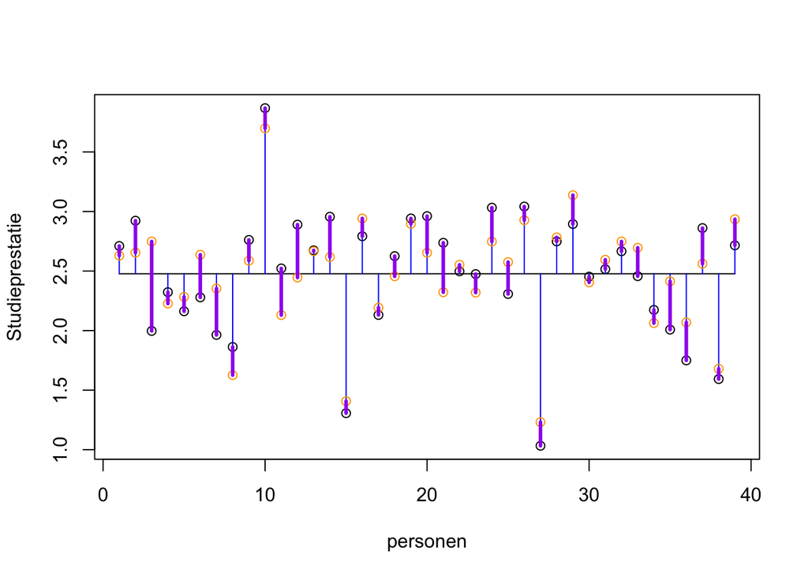

```r
plot(Studieprestatie, xlab='personen', ylab='Studieprestatie')

n = length(Studieprestatie)
gemiddelde.studieprestatie = mean(Studieprestatie)

## Voeg het gemiddelde toe
lines(c(1, n), rep(gemiddelde.studieprestatie, 2))

## Wat is de totale variantie?
segments(1:n, Studieprestatie, 1:n, gemiddelde.studieprestatie, col='blue')

## Wat zijn onze verwachte scores op basis van dit regressie model?
points(model, col='orange')

## Hoever zitten we ernaast, wat is de error?
segments(1:n, Studieprestatie, 1:n, model, col='purple', lwd=3)
```

## Verklaarde variantie

De verklaarde variantie is dat deel van de afwijking ten opzichte van het gemiddelde die het model overeen heeft met de outcome.

In percentage moet dat worden afgezet tegen de totale variantie, dit wordt ook wel $r^2$ of $R^2$ genoemd.

Waarom?

```r
r = cor(Studieprestatie, model)
r^2
```

```
## [1] 0.752754
```